# Assignment 1: PyTorch Basics

### Part B-4(v) [1pt EXPLORATORY]

Using the models you trained in earlier subparts of Part B-4, plot a heatmap of validation errors across at least two hyperparameters (e.g., batch size vs. learning rate). Make sure to select at least two values for each hyperparameter and train the model for all combinations. The rows correspond to different batch sizes, the columns correspond to different learning rates, and the cell values are the validation errors.

Briefly explain any trends you observe and what they suggest about the effect of these hyperparameters.

Hint: A heatmap is simply a color-coded grid where each cell’s color represents a numerical value. For example, here’s a small heatmap created with random values:

`random_vals = np.random.rand(3, 4)`

`sns.heatmap(random_vals, annot=True, fmt=".2f")`

`plt.title("Example Heatmap with Random Values")`

`plt.show()`

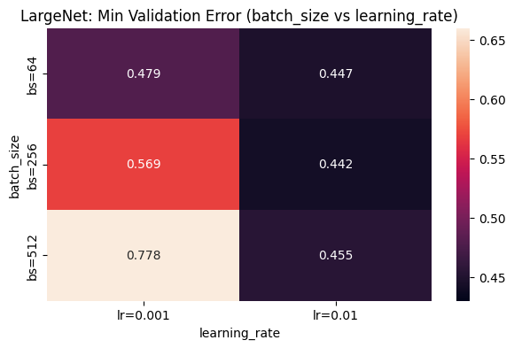

```python
# TO BE COMPLETED

# choose the grid
batch_sizes = [64, 256, 512]
learning_rates = [0.001, 0.01]

# store min validation error for each (bs, lr)
val_err_mat = np.zeros((len(batch_sizes), len(learning_rates)))

for i, bs in enumerate(batch_sizes):
    for j, lr in enumerate(learning_rates):
        prefix = get_model_name("large", bs, lr, epoch=29)
        csv_path = os.path.join(save_dir, prefix + "_val_err.csv")

        val_err = np.loadtxt(csv_path)
        val_err_mat[i, j] = val_err.min()  # best checkpoint across epochs

# heatmap
df = pd.DataFrame(
    val_err_mat,
    index=[f"bs={bs}" for bs in batch_sizes],
    columns=[f"lr={lr}" for lr in learning_rates]
)

plt.figure(figsize=(7, 4))
sns.heatmap(df, annot=True, fmt=".3f", vmin=0.43, vmax=0.66)
plt.title("LargeNet: Min Validation Error (batch_size vs learning_rate)")
plt.xlabel("learning_rate")
plt.ylabel("batch_size")
plt.show()
```

```python
'''
PROVIDE YOUR ANSWER BELOW


From the heatmap, the learning rate has the largest impact on validation performance.

Across all batch sizes, lr=0.01 consistently achieves lower validation error than lr=0.001 (around 0.44–0.46 vs. 0.48–0.78).
This suggests lr=0.001 is too small for a 30-epoch run, and the updates are too conservative,
making training progress slow, and the model tends to underfit within the given training conditions.

Batch size has a secondary effect and interacts with the learning rate. With lr=0.01, a medium batch size performs best.

bs=256 gives the lowest validation error (0.442). This is slightly better than bs=64 (0.447) and bs=512 (0.455).

This likely reflects a trade-off where gradients are stable enough to generalize well without reducing the number of parameter updates too much.

In contrast, when lr=0.001, increasing batch size significantly worsens validation error ( bs=512 reaches 0.778),
because fewer updates per epoch combined with a small step size makes learning even slower.



'''
```

## Part B-5. Evaluating the Best Model

### Part B-5(i) [2pt MODEL]

Summarize in a table the results achieved on training and validation on all your model selections in all parts. This includes choice of `small_net` vs `large_net`, the `batch_size`, `learning_rate`, **and the epoch number**. Hint: you can import the Pandas module to create tables.

Then upon reviewing the results choose your **best** model and load the model checkpoint. You can modify the code below to load your chosen set of weights to the model object `net`.

```python
net = LargeNet()
model_path = os.path.join(save_dir, get_model_name(net.name, batch_size=64, learning_rate=0.01, epoch=10))
state = torch.load(model_path)
net.load_state_dict(state)
```

```
<All keys matched successfully>
```

```python
# TO BE COMPLETED


import glob
device = torch.device("cuda" if torch.cuda.is_available() else "cpu")

def parse_filename(path):
    # e.g. model_large_bs256_lr0.01_epoch29_val_err.csv
    base = os.path.basename(path)
    parts = base.split("_")
    net = parts[1]                      # small / large
    bs = int(parts[2].replace("bs","")) # 256
    lr = float(parts[3].replace("lr",""))# 0.01
    epoch = int(parts[4].replace("epoch","")) # 29
    return net, bs, lr, epoch

rows = []

# 1) read csv
val_err_files = glob.glob(os.path.join(save_dir, "*_val_err.csv"))

for f in val_err_files:
    net, bs, lr, epoch = parse_filename(f)
    val_err = np.loadtxt(f)          # length = num_epochs
    min_val_err = float(val_err.min())
    best_epoch = int(val_err.argmin())   # 0-based
    rows.append({
        "net": net,
        "batch_size": bs,
        "learning_rate": lr,
        "trained_until_epoch": epoch,
        "min_val_err": min_val_err,
        "best_epoch": best_epoch
    })

df = pd.DataFrame(rows).sort_values("min_val_err").reset_index(drop=True)
df
```

|  | net | batch_size | learning_rate | trained_until_epoch | min_val_err | best_epoch |
| --- | --- | --- | --- | --- | --- | --- |
| 0 | large | 256 | 0.010 | 29 | 0.441799 | 22 |
| 1 | large | 64 | 0.010 | 29 | 0.447090 | 10 |
| 2 | large | 512 | 0.010 | 29 | 0.455026 | 28 |
| 3 | small | 64 | 0.010 | 29 | 0.470899 | 4 |
| 4 | large | 64 | 0.001 | 29 | 0.478836 | 12 |
| 5 | large | 256 | 0.001 | 29 | 0.568783 | 27 |
| 6 | large | 16 | 0.010 | 29 | 0.592593 | 4 |
| 7 | large | 64 | 0.100 | 29 | 0.740741 | 16 |
| 8 | large | 512 | 0.001 | 29 | 0.777778 | 14 |

```python
# TO BE COMPLETED

best = df.iloc[0]
print("Best run:", dict(best))

# 2) build the matching network
if best["net"] == "large":
    net = LargeNet()
else:
    net = SmallNet()
net = net.to(device)

# 3) load the checkpoint at best_epoch
model_path = os.path.join(
    save_dir,
    get_model_name(net.name, best["batch_size"], best["learning_rate"], int(best["best_epoch"]))
)

state = torch.load(model_path, map_location=device)
net.load_state_dict(state)
net.eval()

print("Loaded checkpoint:", model_path)
```

```
Best run: {'net': 'large', 'batch_size': np.int64(256), 'learning_rate': np.float64(0.01), 'trained_until_epoch': np.int64(29), 'min_val_err': np.float64(0.4417989417989418), 'best_epoch': np.int64(22)}
Loaded checkpoint: /content/drive/MyDrive/garbage_model_runs/model_large_bs256_lr0.01_epoch22
```